# Worked example: iron by visible absorption

## Chemical question and measurement

These simulated data describe supplied filtered, fortified waters. Under the assumed quantitative reduction and complex formation, dissolved iron forms [Fe(phen)₃]²⁺ and is measured at 510 nm in a 1.00 cm cell. Results refer to mg elemental Fe/L in the supplied filtered water. They do not establish particulate iron, original oxidation-state speciation, or validated total recovery from arbitrary water matrices.

Standards, samples, and independent QC receive matched colour development. Absorbances are already reagent-blank referenced. The remaining fitted offset is retained; its source cannot be identified from these data alone.

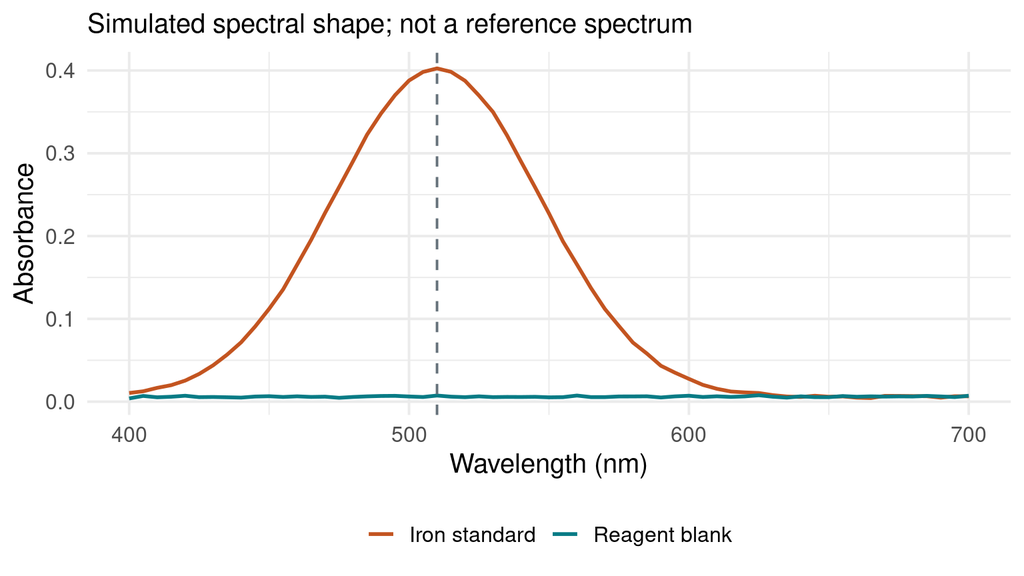

Illustrative simulated spectra, not identification reference spectra.

## Calibration and checks

The fitted response is A = 0.003874 + 0.198799 × c, where c is mg Fe/L in the final coloured solution. The slope is in L/mg Fe; the response is dimensionless. We fit absorbance on concentration, then invert the fitted relation.

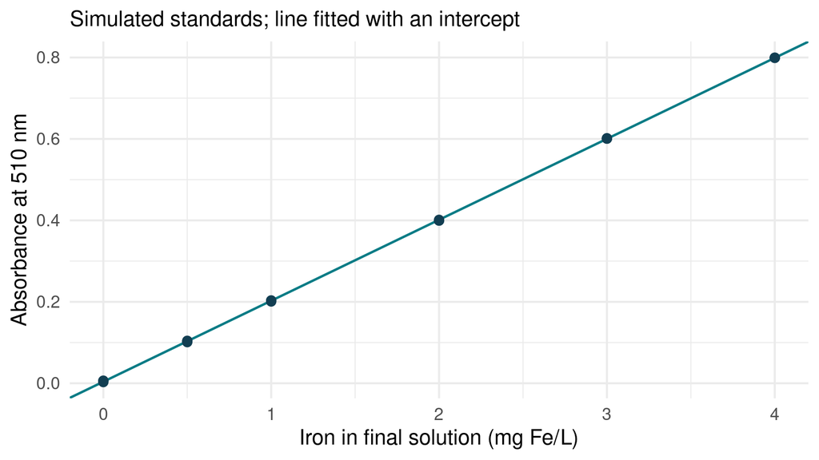

Three independently prepared calibration solutions per concentration.

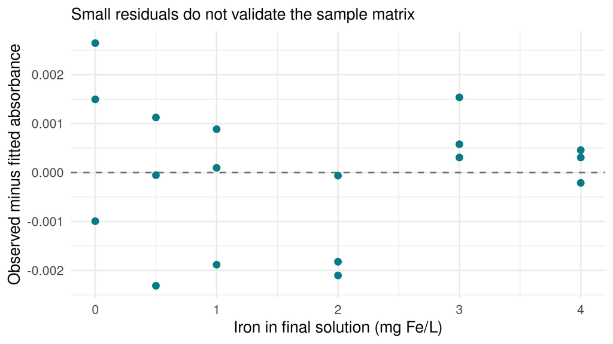

Small residuals support this teaching linear model, but cannot validate sample matrix recovery.

The calibration covers 0–4 mg Fe/L. The supplied decision rule requires all repeat readings within the fitted response range. Independent QC must recover 95–105% of its 2.00 mg Fe/L reference value, a teaching window selected for this exercise.

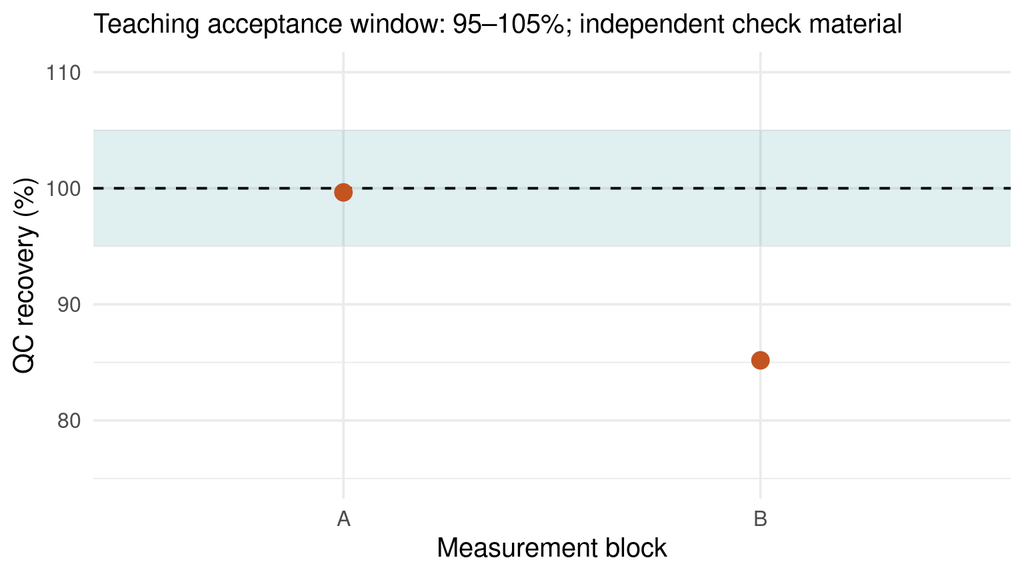

Independent QC for accepted block A and later block B.

| block | mean_absorbance | reference_mg_l | estimated_mg_l | recovery_percent | qc_pass |
| --- | --- | --- | --- | --- | --- |
| A | 0.400 | 2 | 1.993 | 99.647 | TRUE |
| B | 0.343 | 2 | 1.704 | 85.176 | FALSE |

Block A is accepted by the exercise check. Later block B fails. P05 therefore cannot be reported. A correction based solely on its QC ratio would assume the cause of the error; investigation and new satisfactory measurements are needed. A passing QC also cannot exclude all sample-specific interferences.

## Preparation and supported results

Measurements are joined by preparation ID to the reversed preparation table. P01 and P02 are separate preparations of W1, each read three times. They are not six independent water samples. Their shared calibration also means their uncertainties are correlated.

| preparation_id | sample_id | mean_absorbance | dilution_factor | original_mg_l | u_original_mg_l | status |
| --- | --- | --- | --- | --- | --- | --- |
| P01 | W1 | 0.4806 | 5 | 11.9906 | 0.0277 | reportable under stated assumptions |
| P02 | W1 | 0.4849 | 5 | 12.0987 | 0.0278 | reportable under stated assumptions |
| P03 | W2 | 1.0751 | 5 | NA | NA | remeasure: outside range |
| P04 | W2 | 0.5406 | 10 | 26.9989 | 0.0650 | reportable under stated assumptions |
| P05 | W3 | 0.3097 | 5 | NA | NA | withhold: QC failed |

P01 gives 11.991 mg Fe/L; its factor is 50/10=5. P03 is outside range. P04 is a new preparation using 5.00 mL made to 50.00 mL, and gives 26.999 mg Fe/L with factor 10. It is not an extrapolation of P03’s old reading. The CSV retains the reasons for withheld values and exports their concentration fields as `NA`.

## Uncertainty and its limits

The supplied helper uses a first-order inverse-calibration approximation. For P01 it includes the variance of the mean of three readings and the covariance of the fitted intercept and slope. The calibration residual SD estimates response noise. Its approximate 95% interval applies to the final solution under normal, independent, constant-variance response errors, negligible standard-concentration uncertainty, and a well-determined positive slope.

```
##   final_mg_l u_cal_mg_l lower_95_mg_l upper_95_mg_l
## 1   2.398127 0.00450904      2.388568      2.407686
```

The independent volume contributions are then combined with the calibration and reading contribution by root-sum-of-squares. The result for P01 is 11.991 mg Fe/L with a **standard uncertainty** of 0.028 mg Fe/L, not a 95% half-width.

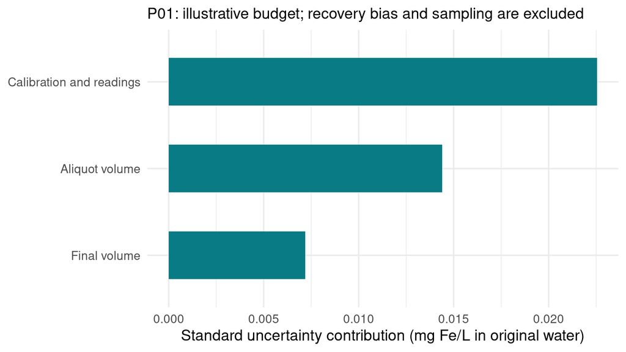

Standard uncertainty contributions in the original-water concentration for P01.

This is a conditional teaching budget: it omits sampling, standard preparation uncertainty, recovery, matrix bias, and unmodelled variation between preparations. The two preparations are not sufficient to validate those omissions or claim a full method uncertainty. A real report must evaluate the assumptions before claiming the result is fit for its intended purpose.

## Transfer result

For the new 2.00 mL aliquot made up to 50.00 mL, mean absorbance is 0.400. The estimated final concentration is 1.9926 mg Fe/L. Multiplying by 25 gives **49.81 mg Fe/L** in the original supplied sample, assuming accepted block A and matching chemistry. This remains a point estimate until its own uncertainty is evaluated.